# A Happy Country: What does it like?

### About this project

What makes a happy country? Is it the country's economy, politics, or its people? Using data from the **WInternational Database (IDB)** by United States Census Bureau and **World Happiness Report Dataset** by the World Happiness Report (WHR) organization, I will address this question by identifying factors that are indicative of citizen happiness.

### Goals

Using data from 2007 - 2023, this project will answer the following questions:

1. What are the top 10 happiest countries in the world?
2. What the the top 10 richest countries in the world?
3. As of 2023, what are the top 10 countries with the highest population in the world?
4. What are some indicators of happiness?

### Method

Data was collected from the US Census Bereau and the World Happiness Record organizations for this analysis. (see References for details). \ Because multiple predictors will be used to predict happiness, a multiple linear model will be conducted. Prior to data analysis, data cleaning will be applied to treat missing values (NA), duplicates, and outliers.

### Variables of Interest

|  | Variable Name | Definition |
| --- | --- | --- |
| Outcome | Happiness | Measured by WHR, a subjective report of happiness. Higher value indicates higher happiness. |
| Predictor | Log GDP | Gross Domestic Product per capita in international dollars (logged) measures the economic growth of a country. Higher value indicates higher economic growth |
| Predictor | Social Support | Measured by WHR, a binary response with 0 (No social support) and 1 (Social support). |
| Predictor | Generosity | Measured by WHR, a binary response asking participant whether they have donated to charity in the previous year |
| Predictor | Freedom to Make Life Choices (Freedom) | Measured by WHR, a binary response with 0 ("I do not have the freedom to make my life choices") and 1 ("I have freedom to make important life choices). Higher values indicates higher freedom to make l… |
| Predictor | Healthy life expectancy | measured by WHR, Average number of years that a person can expect to live in "full health" by taking into account years lived in less than full health due to disease and/or injury. |
| Predictor | Median Age | A median age of a country population |
| Predictor | Fertility Rate | The number of babies that were born by women in their fertile years. Lower fertility rate indicates few babies were born in such year |
| Predictor | Perception of Corruption | Measured by WHR, this number is the average of two binary-response questions, one concerns with corruption in government and the other concerns with corruption in business. Higher value indicates high… |
| Predictor | Crude birth rate | the total number of live human births per 1,000 population for a given period divided by the length of the period in years. |
| Predictor | Life Expectancy at Birth | the number of years a newborn infant would live if prevailing patterns of mortality at the time of its birth were to stay the same throughout its life. |
| Predictor | Crude Death Rate | Number of deaths over a given period divided by the person-years lived by the population over that period. |
| Predictor | Infant Mortality Rate | the probability of a child born in a specific year or period dying before reaching the age of one, if subject to age-specific mortality rates of that period |
| Predictor | Net Migration Rate | the number of immigrants minus the number of emigrants, including citizens and noncitizens. |

# LIBRARY & DATASET

### LIBRARY

```python
# Data Table
import numpy as np                       # matrices & arrays
import pandas as pd                      # Data Table & dataframe

# Visualization
import seaborn as sns
import matplotlib.pyplot as plt

# Hypothesis Testing
import scipy.stats as sps                 # statistical tests
from scipy.stats.mstats import winsorize  # Winsorizing
import statsmodels.api as sm              # regression
from statsmodels.formula.api import ols   # regression model
from sklearn.preprocessing import StandardScaler   # Standardize data

# Options
import warnings
warnings.filterwarnings('ignore')         # suppress all warnings; switch 'ignore' to 'default' to to re-enable it again
pd.set_option('display.max_rows', 500)    # display max rows
pd.set_option('display.max_columns', 500) #         max cols
pd.set_option('display.width', 1000)      #         max width
pd.set_option('display.precision', 2)     #         round 2 places after decimal
```

### FUNCTIONS

##### nadup()

```python
# Functions for calculation
def nadup(df):
    arr, arr2, arr3, arr4 = [], [], [], []
    for col in df.columns:
      temp = [str(x) for x in df[col].unique()]    # convert cols to str
      temp2 = df[col].isna().sum()                 # calculate sum of NaN
      temp3 = (df[col].isna().sum())/len(df)*100   # calculate % of NaN
      arr.append(', '.join(temp))
      arr2.append(len(temp))
      arr3.append(temp2)
      arr4.append(round(temp3,1))
    print('The dataframe has a total of %i rows & %i columns. A total of %i NA values were detected.\n' %(df.shape[0],df.shape[1],df.isnull().any(axis=1).sum()),
          ' This dataframe has',df.duplicated().sum(),'duplicated rows')
    summary = pd.DataFrame({
        'Variables': df.columns,
        'Type':df.dtypes.to_list(),
        'Unique Values':arr,
        'Sum of Unique Values': arr2,
        'Sum of NaN Values': arr3,
        '% of NaN': arr4}).sort_values('% of NaN', ascending = False)
    display(summary)
```

##### correport()

```python
# criteria: r > threshold
def correport(df,var,threshold):
    numeric_var = df.select_dtypes(include = 'number')
    numeric_corr = numeric_var.corr()[var][:-1] # -1 means that the latest row
    top_features = numeric_corr[abs(numeric_corr) >= threshold].sort_values(ascending=False) #displays pearsons correlation coefficient greater than threshold
    print("There is %i variables (with r >= %.2f) correlated with %s:" %(len(top_features)-1, threshold, var))
    print(top_features[top_features <1])   # because a variable of 1 is itself
    for i in range(0, len(numeric_var.columns), 5):
        sns.pairplot(data=numeric_var,
                     x_vars=numeric_var.columns[i:i+5],
                     y_vars=[var])
```

##### outlier()

```python
# Define Normal_outlier test
def outlier(var):
    '''
    Visualization
    '''
    fig, ax = plt.subplots(1,2)                          # Making (row, col) of plots
    fig.set_figheight(4)                                 # set height
    fig.set_figwidth(6)                                  # set width
    sns.set(style = 'white')                         # Style (style, palette argument)
    sns.boxplot(y = var, ax= ax[0])                      # Boxplot
    sm.qqplot(var, fit = True, line = '45', ax = ax[1])  # qqplot
    fig.tight_layout()                                   # Tight layout
    plt.show()                                           # show plots
    '''
    Descriptive Statistics Table
    '''
    mode = sps.mode(var)
    n = len(var)
    from prettytable import PrettyTable
    summary = PrettyTable(["Descriptive Statistics", ""])
    summary.add_row(["Sample Size", n])
    summary.add_row(["Mean", round(var.mean(),3)])
    summary.add_row(["Median", round(var.median(),3)])
    summary.add_row(["Mode", mode.mode])
    summary.add_row(["Max", var.max()])
    summary.add_row(["Min", var.min()])
    summary.add_row(["Range", round(var.max() - var.min(),3)])
    summary.add_row(["Standard Deviation", round(var.std(),3)])
    summary.add_row(["Variance", round(var.var(),3)])
    print(summary,'\n')
    '''
    Outliers Calculation using IQR
    '''
    q1, q3= np.percentile(var, [25, 75])  # q1,q3 calc
    iqr = q3 - q1                         # iqr calc
    lower = q1 - (1.5 * iqr)              # lower bound
    upper = q3 + (1.5 * iqr)              # upper bound
    outliers = [x for x in var if x < lower or x > upper]                          # outliers identified
    print('Using the IQR Method, the following outliers were identified:','\n',   # print out the outliers
          'The lower bound is:', round(lower,4),'\n',
          'The upper bound is:', round(upper,4),'\n',
          'Unique Outliers are:', set(outliers),'\n',
          'The total number of outliers are:',len(outliers))
    print('\n')
```

##### winsor_try()

```python
# define function winsor_try()
def winsor_try1(var, lower, upper):
    from scipy.stats.mstats import winsorize             # Winsorizing
    var = winsorize(var,limits=[lower,upper])
    '''
    Outliers Calculation using IQR
    '''
    q1, q3= np.percentile(var, [25, 75])                 # q1,q3 calc
    iqr = q3 - q1                                        # iqr calc
    lower_bound = round(q1 - (1.5 * iqr),3)              # lower bound
    upper_bound = round(q3 + (1.5 * iqr),3)              # upper bound
    outliers = [x for x in var if x < lower_bound or x > upper_bound]
    print('Outliers:', set(outliers),'\n',
          'number of outliers =', len(outliers),'| Upper bound=', upper_bound,'| Lower bound =',lower_bound)

def winsor_try(var):
    print('Winsorizing at 1%')
    winsor_try1(var,.01,.01)
    print('\nWinsorizing at 2.5%')
    winsor_try1(var,.025,.025)
    print('\nWinsorizing at 5%')
    winsor_try1(var,.05,.05)
    print('\nWinsorizing at 10%')
    winsor_try1(var,.1,.1)
    print('\nWinsorizing at 15%')
    winsor_try1(var,.15,.15)
```

##### multiple_lr()

```python
def multiple_lr(df,outcome):
    '''
    Setup & run OLS model
    '''
    predictor = df.drop(outcome, axis = 1)            # grab the predictors
    x1 = sm.add_constant(predictor)                   # build the Lease-squared model
    model = sm.OLS(df_standard[outcome],x1).fit()
    summary = model.summary()                         # print Model summary
    print(' ==========================================\n',
          '              RESULT REPORTING             \n'
          ' ==========================================')
    '''
    APA Reporting
    '''
    if model.f_pvalue < alpha:                       # these codes refer to the Model reproting (F-statistics)
        print(' A multiple linear regression model to predict %s from multiple predictors was significant,' %outcome,
              'F(%i,%i) = %.3f, p < %.2f. \n' %(model.df_model,model.df_resid,model.fvalue,alpha),
              'This model explains %.2f percent of variance in %s, Adjusted R-squared = %.3f. \n \n' %(model.rsquared_adj*100,outcome,model.rsquared_adj))
        print(summary, '\n')
        '''
        Set-up for additional report
        '''
        p_values = model.pvalues[1:]                    # these codes grab parameters from model (using dict(model))
        predictors_names = predictor.columns.tolist()   #            Creating arrays of interested metrics
        outcomes_names = np.repeat(outcome,len(predictors_names))
        df_between = np.repeat(model.df_model,len(predictors_names))
        df_within = np.repeat(model.df_resid,len(predictors_names))
        t_values = model.tvalues[1:]
        slopes = model.params[1:]
        alphas = np.repeat(alpha,len(predictors_names))
        significant, not_significant, direction = [], [], []
        # First forloops to identify whether a slope increase or decrease (to report later)
        for slope in slopes:
            if slope < 0:
                direction.append('decreases')
            elif slope > 0:
                direction.append('increases')
            else:
                direction.append('does not change')
        print(' ============================================\n',
              '            SIGNIFICANT PREDICTORS            \n'
              ' ============================================')
        '''
        Forloops to report significant predictors
        '''
        # print significant predictors apa format, for insignificant just append them to not_significant
        for a,b,c,d,e,f,g,h, direction in zip(p_values,predictors_names, outcomes_names, df_between, df_within, t_values, alphas, slopes, direction):
            if a < alpha:
                print('%s significantly predicts %s, t(%i,%i) = %.2f, p <%.2f. \n' %(b,c,d,e,f,g),
                      'For every unit increase in %s, %s %s by %.3f unit. \n' %(b,c,direction,abs(h)))
                significant.append(b)        # this gives the total reporting later
            else:
                not_significant.append(b)
        print('In total, %i out of %i predictors were significant. \n' %(len(significant),len(predictors_names)))
        print(' ==============================================\n',
              '            INSIGNIFICANT PREDICTORS          \n'
              ' ==============================================')
        print('These remaining %i predictors do not significantly predict %s, p > %.2f \n' %(len(not_significant),outcome,alpha),
              not_significant)
    else:     # a report of insignificant model
        print('A multiple linear regression model to predict %s from multiple predictors was not significant,' %outcome,
              'F(%i,%i) = %.3f, p >%.2f.' %(model.df_model,model.df_resid,model.fvalue,alpha))
```

### DATASET

##### Importing

```python
# Import Population Data
population_orig = pd.read_csv('population by country.csv')
dictionary_df = pd.read_csv('stats.csv')
country_code = pd.read_csv('country code.csv')

# Import World Happiness Data
whr2023 = pd.read_csv('whr 2023.csv')
whr_pre2023 = pd.read_csv('whr 2008-2022.csv')
```

##### population_orig

```python
# Shape of dataset
print('The data table has %i rows & %i columns' %(population_orig.shape[0],population_orig.shape[1]))

# Rename
population_orig.columns = ['country','region1','genc','year','population','median_age','fertility_rate','crude_birth_rate',
                           'life_expectancy_at_birth','infant_mortality_rate','crude_death_rate','net_migration_rate']

# A glimpse of the data table
population_orig.head()
```

```
The data table has 3875 rows & 12 columns
```

|  | country | region1 | genc | year | population | median_age | fertility_rate | crude_birth_rate | life_expectancy_at_birth | infant_mortality_rate | crude_death_rate | net_migration_rate |
| --- | --- | --- | --- | --- | --- | --- | --- | --- | --- | --- | --- | --- |
| 0 | Afghanistan | 2007,Afghanistan | AF | 2007.0 | 27385162 | 16.8 | 6.16 | 40.7 | 47.8 | 133.6 | 15.9 | -34.6 |
| 1 | Albania | 2007,Albania | AL | 2007.0 | 2991573 | 28.7 | 1.45 | 11.2 | 78.3 | 12.2 | 4.9 | -9.7 |
| 2 | Algeria | 2007,Algeria | DZ | 2007.0 | 34002255 | 25 | 2.61 | 23 | 74.8 | 27.8 | 4.3 | -1.1 |
| 3 | American Samoa | 2007,American Samoa | AS | 2007.0 | 56765 | 21.9 | 3.37 | 22.8 | 73.1 | 11.6 | 4.4 | -26 |
| 4 | Andorra | 2007,Andorra | AD | 2007.0 | 80757 | 38.5 | 1.31 | 10.7 | 82.8 | 3.6 | 5.3 | 21.5 |

##### whr2023

```python
# Shape of dataset
print('The data table has %i rows & %i columns' %(whr2023.shape[0],whr2023.shape[1]))

# A glimpse of the data table
whr2023.head()
```

```
The data table has 137 rows & 19 columns
```

|  | Country name | Ladder score | Standard error of ladder score | upperwhisker | lowerwhisker | Logged GDP per capita | Social support | Healthy life expectancy | Freedom to make life choices | Generosity | Perceptions of corruption | Ladder score in Dystopia | Explained by: Log GDP per capita | Explained by: Social support | Explained by: Healthy life expectancy | Explained by: Freedom to make life choices | Explained by: Generosity | Explained by: Perceptions of corruption | Dystopia + residual |
| --- | --- | --- | --- | --- | --- | --- | --- | --- | --- | --- | --- | --- | --- | --- | --- | --- | --- | --- | --- |
| 0 | Finland | 7.80 | 0.04 | 7.88 | 7.73 | 10.79 | 0.97 | 71.15 | 0.96 | -0.02 | 0.18 | 1.78 | 1.89 | 1.58 | 0.54 | 0.77 | 0.13 | 0.54 | 2.36 |
| 1 | Denmark | 7.59 | 0.04 | 7.67 | 7.51 | 10.96 | 0.95 | 71.25 | 0.93 | 0.13 | 0.20 | 1.78 | 1.95 | 1.55 | 0.54 | 0.73 | 0.21 | 0.53 | 2.08 |
| 2 | Iceland | 7.53 | 0.05 | 7.62 | 7.43 | 10.90 | 0.98 | 72.05 | 0.94 | 0.21 | 0.67 | 1.78 | 1.93 | 1.62 | 0.56 | 0.74 | 0.25 | 0.19 | 2.25 |
| 3 | Israel | 7.47 | 0.03 | 7.54 | 7.41 | 10.64 | 0.94 | 72.70 | 0.81 | -0.02 | 0.71 | 1.78 | 1.83 | 1.52 | 0.58 | 0.57 | 0.12 | 0.16 | 2.69 |
| 4 | Netherlands | 7.40 | 0.03 | 7.46 | 7.35 | 10.94 | 0.93 | 71.55 | 0.89 | 0.21 | 0.38 | 1.78 | 1.94 | 1.49 | 0.55 | 0.67 | 0.25 | 0.39 | 2.11 |

##### whr_pre2023

```python
# Shape of dataset
print('The data table has %i rows & %i columns' %(whr_pre2023.shape[0],whr_pre2023.shape[1]))

# A glimpse of the data table
whr_pre2023.head()
```

```
The data table has 2199 rows & 11 columns
```

|  | Country name | year | Life Ladder | Log GDP per capita | Social support | Healthy life expectancy at birth | Freedom to make life choices | Generosity | Perceptions of corruption | Positive affect | Negative affect |
| --- | --- | --- | --- | --- | --- | --- | --- | --- | --- | --- | --- |
| 0 | Afghanistan | 2008 | 3.72 | 7.35 | 0.45 | 50.5 | 0.72 | 0.17 | 0.88 | 0.41 | 0.26 |
| 1 | Afghanistan | 2009 | 4.40 | 7.51 | 0.55 | 50.8 | 0.68 | 0.19 | 0.85 | 0.48 | 0.24 |
| 2 | Afghanistan | 2010 | 4.76 | 7.61 | 0.54 | 51.1 | 0.60 | 0.12 | 0.71 | 0.52 | 0.28 |
| 3 | Afghanistan | 2011 | 3.83 | 7.58 | 0.52 | 51.4 | 0.50 | 0.16 | 0.73 | 0.48 | 0.27 |
| 4 | Afghanistan | 2012 | 3.78 | 7.66 | 0.52 | 51.7 | 0.53 | 0.24 | 0.78 | 0.61 | 0.27 |

##### dictionary_df

```python
# Shape of dataset
print('The data table has %i rows & %i columns' %(dictionary_df.shape[0],dictionary_df.shape[1]))

# pick columns
dictionary_df = dictionary_df[['Country or Area','Continent','Region 1']]

# rename columns
dictionary_df.columns = ['country','continent','region']

# A glimpse of the data table
dictionary_df.head()
```

```
The data table has 249 rows & 7 columns
```

|  | country | continent | region |
| --- | --- | --- | --- |
| 0 | Afghanistan | Asia | Southern Asia |
| 1 | Åland Islands | Europe | Northern Europe |
| 2 | Albania | Europe | Southern Europe |
| 3 | Algeria | Africa | Northern Africa |
| 4 | American Samoa | Oceania | Polynesia |

### MERGING TABLES

##### population

```python
# Merge dictionary_df to population
population = population_orig.merge(dictionary_df,
                              on = 'country', how = 'left')

# pick columns
population_df = population.drop(columns = ['region1','genc','year','population','continent','region'])
```

```python
# cols to convert
col_to_convert = ['median_age','fertility_rate','crude_birth_rate',
               'life_expectancy_at_birth','infant_mortality_rate',
               'crude_death_rate','net_migration_rate']

# convert type
population_df[col_to_convert] = population_df[col_to_convert].apply(pd.to_numeric, errors='coerce')
```

##### population_df_summary

```python
# Average by country from 2007 - 2023
population_df_summary = population_df.groupby('country').agg({'median_age': 'mean',
                                                     'fertility_rate':'mean',
                                                     'crude_birth_rate':'mean',
                                                     'life_expectancy_at_birth':'mean',
                                                     'infant_mortality_rate':'mean',
                                                     'crude_death_rate':'mean',
                                                     'net_migration_rate':'mean'}).reset_index()

# re-attached the region & continent
population_df_summary = population_df_summary.merge(dictionary_df,
                              on = 'country', how = 'left')

# Remove all NA rows
population_df_summary = population_df_summary.dropna()
```

##### happiness_df

```python
# Create an array of 2023
year = np.array([2023]*len(whr2023))

# add year into whr2023
whr2023['year'] = year.tolist()

# create whr2023_df
whr2023_df = whr2023[['Country name','year','Ladder score','Logged GDP per capita',
                      'Social support','Healthy life expectancy','Freedom to make life choices',
                      'Generosity','Perceptions of corruption']]

whr2023_df.columns = ['country','year','happiness','log_gdp','social_support',
                      'healthy_life_expectancy','freedom','generosity','corruption_perception']

# create whr_pre2023_df
whr_pre2023_df = whr_pre2023[['Country name','year','Life Ladder','Log GDP per capita',
                      'Social support','Healthy life expectancy at birth','Freedom to make life choices',
                      'Generosity','Perceptions of corruption']]

whr_pre2023_df.columns = ['country','year','happiness','log_gdp','social_support',
                      'healthy_life_expectancy','freedom','generosity','corruption_perception']

# happiness
happiness_df = pd.concat([whr2023_df, whr_pre2023_df], axis=0)

# subset df (only include 2007 - 2023 data)
happiness_df = happiness_df[happiness_df['year'] >= 2007]
```

# DATA CLEANING

### NA Treatment: happiness_df

##### Duplicates & NA check

```python
nadup(happiness_df)
```

```
The dataframe has a total of 2220 rows & 9 columns. A total of 196 NA values were detected.
  This dataframe has 0 duplicated rows
```

|  | Variables | Type | Unique Values | Sum of Unique Values | Sum of NaN Values | % of NaN |
| --- | --- | --- | --- | --- | --- | --- |
| 8 | corruption_perception | float64 | 0.182, 0.196, 0.668, 0.708, 0.379, 0.202, 0.28... | 605 | 108 | 4.9 |
| 5 | healthy_life_expectancy | float64 | 71.15, 71.25, 72.05, 72.697, 71.55, 72.15, 71.... | 1135 | 54 | 2.4 |
| 7 | generosity | float64 | -0.019, 0.134, 0.211, -0.023, 0.213, 0.165, 0.... | 628 | 39 | 1.8 |
| 6 | freedom | float64 | 0.961, 0.934, 0.936, 0.809, 0.887, 0.948, 0.94... | 540 | 28 | 1.3 |
| 3 | log_gdp | float64 | 10.792, 10.962, 10.896, 10.639, 10.942, 10.883... | 1675 | 19 | 0.9 |
| 4 | social_support | float64 | 0.969, 0.954, 0.983, 0.943, 0.93, 0.939, 0.92,... | 480 | 13 | 0.6 |
| 0 | country | object | Finland, Denmark, Iceland, Israel, Netherlands... | 164 | 0 | 0.0 |
| 1 | year | int64 | 2023, 2008, 2009, 2010, 2011, 2012, 2013, 2014... | 17 | 0 | 0.0 |
| 2 | happiness | float64 | 7.804, 7.586, 7.53, 7.473, 7.403, 7.395, 7.315... | 1714 | 0 | 0.0 |

##### corruption_perception

```python
# rows with NA values: corruption_perception
missing_corrupt = happiness_df[happiness_df['corruption_perception'].isnull()]

# Number of countries with missing corrupt
print('Countries with missing values for corruption: \n',
      missing_corrupt.groupby('country').size().sort_values(ascending = False))
```

```
Countries with missing values for corruption:
 country
China                   15
Saudi Arabia            14
United Arab Emirates    12
Jordan                  11
Turkmenistan            10
Kuwait                   7
Egypt                    6
Bahrain                  6
Malta                    5
Qatar                    4
Yemen                    3
Vietnam                  3
Uzbekistan               2
Algeria                  2
Libya                    2
Oman                     1
Maldives                 1
Laos                     1
Ethiopia                 1
Congo (Brazzaville)      1
Cambodia                 1
dtype: int64
```

**NA Values Treatment.** \ Sample mean substitution will be used.

```python
# Sample mean substitution
happiness_df['corruption_perception'] = happiness_df.groupby('country')['corruption_perception'].transform(lambda x: x.fillna(x.mean()))

# Check to see if there are still NA values
happiness_df[happiness_df['corruption_perception'].isnull()]
```

|  | country | year | happiness | log_gdp | social_support | healthy_life_expectancy | freedom | generosity | corruption_perception |
| --- | --- | --- | --- | --- | --- | --- | --- | --- | --- |
| 1207 | Maldives | 2018 | 5.20 | 9.89 | 0.91 | 69.78 | 0.85 | 1.60e-02 | NaN |
| 1485 | Oman | 2011 | 6.85 | 10.54 | NaN | 62.34 | 0.92 | 1.00e-02 | NaN |
| 1996 | Turkmenistan | 2009 | 6.57 | 8.96 | 0.92 | 59.78 | NaN | -1.02e-01 | NaN |
| 1997 | Turkmenistan | 2011 | 5.79 | 9.15 | 0.96 | 60.42 | NaN | 1.80e-02 | NaN |
| 1998 | Turkmenistan | 2012 | 5.46 | 9.23 | 0.95 | 60.74 | 0.79 | -1.23e-01 | NaN |
| 1999 | Turkmenistan | 2013 | 5.39 | 9.31 | 0.85 | 61.06 | 0.70 | -7.20e-02 | NaN |
| 2000 | Turkmenistan | 2014 | 5.79 | 9.39 | 0.91 | 61.38 | 0.81 | 3.10e-02 | NaN |
| 2001 | Turkmenistan | 2015 | 5.79 | 9.44 | 0.96 | 61.70 | 0.70 | 9.20e-02 | NaN |
| 2002 | Turkmenistan | 2016 | 5.89 | 9.48 | 0.93 | 61.80 | 0.75 | 4.00e-03 | NaN |
| 2003 | Turkmenistan | 2017 | 5.23 | 9.53 | 0.91 | 61.90 | 0.72 | 6.50e-02 | NaN |
| 2004 | Turkmenistan | 2018 | 4.62 | 9.57 | 0.98 | 62.00 | 0.86 | 2.59e-01 | NaN |
| 2005 | Turkmenistan | 2019 | 5.47 | 9.62 | 0.98 | 62.10 | 0.89 | 2.84e-01 | NaN |

```python
# Maldives
print('MALDIVES ENTRY: \n',
      happiness_df[happiness_df['country'] == 'Maldives'], '\n')

# Oman
print('OMAN ENTRY: \n',
      happiness_df[happiness_df['country'] == 'Oman'], '\n')

# Turkmenistan
print('TURKMENISTAN ENTRY: \n',
      happiness_df[happiness_df['country'] == 'Turkmenistan'], '\n')
```

```
MALDIVES ENTRY:
        country  year  happiness  log_gdp  social_support  healthy_life_expectancy  freedom  generosity  corruption_perception
1207  Maldives  2018        5.2     9.89            0.91                    69.78     0.85        0.02                    NaN

OMAN ENTRY:
      country  year  happiness  log_gdp  social_support  healthy_life_expectancy  freedom  generosity  corruption_perception
1485    Oman  2011       6.85    10.54             NaN                    62.34     0.92        0.01                    NaN

TURKMENISTAN ENTRY:
            country  year  happiness  log_gdp  social_support  healthy_life_expectancy  freedom  generosity  corruption_perception
1996  Turkmenistan  2009       6.57     8.96            0.92                    59.78      NaN   -1.02e-01                    NaN
1997  Turkmenistan  2011       5.79     9.15            0.96                    60.42      NaN    1.80e-02                    NaN
1998  Turkmenistan  2012       5.46     9.23            0.95                    60.74     0.79   -1.23e-01                    NaN
1999  Turkmenistan  2013       5.39     9.31            0.85                    61.06     0.70   -7.20e-02                    NaN
2000  Turkmenistan  2014       5.79     9.39            0.91                    61.38     0.81    3.10e-02                    NaN
2001  Turkmenistan  2015       5.79     9.44            0.96                    61.70     0.70    9.20e-02                    NaN
2002  Turkmenistan  2016       5.89     9.48            0.93                    61.80     0.75    4.00e-03                    NaN
2003  Turkmenistan  2017       5.23     9.53            0.91                    61.90     0.72    6.50e-02                    NaN
2004  Turkmenistan  2018       4.62     9.57            0.98                    62.00     0.86    2.59e-01                    NaN
2005  Turkmenistan  2019       5.47     9.62            0.98                    62.10     0.89    2.84e-01                    NaN
```

```python
# grand mean substitution
happiness_df['corruption_perception'] = happiness_df['corruption_perception'].fillna(happiness_df['corruption_perception'].mean())

# check for NA values
print('Total Number of NA values:', happiness_df['corruption_perception'].isna().sum())
```

```
Total Number of NA values: 0
```

##### Generosity

```python
# Rows with missing data
generosity_na = happiness_df[happiness_df['generosity'].isnull()]

# groupby country
generosity_na.groupby('country').size().sort_values(ascending = False)
```

```
country
Kuwait                      4
South Sudan                 4
Somaliland region           4
Bahrain                     3
Venezuela                   3
United Arab Emirates        3
Taiwan Province of China    3
Algeria                     2
Qatar                       1
State of Palestine          1
South Korea                 1
Afghanistan                 1
Malta                       1
Kosovo                      1
Japan                       1
Iran                        1
Iceland                     1
Germany                     1
Cyprus                      1
Brazil                      1
Vietnam                     1
dtype: int64
```

Per the output above, it seems that these data are missing at random. Missing data will be imputed using **sample mean.**

```python
# Sample mean substitution
happiness_df['generosity'] = happiness_df.groupby('country')['generosity'].transform(lambda x: x.fillna(x.mean()))

# Check to see if there are still NA values
happiness_df[happiness_df['generosity'].isnull()]
```

|  | country | year | happiness | log_gdp | social_support | healthy_life_expectancy | freedom | generosity | corruption_perception |
| --- | --- | --- | --- | --- | --- | --- | --- | --- | --- |
| 1755 | Somaliland region | 2009 | 4.99 | NaN | 0.88 | NaN | 0.75 | NaN | 0.51 |
| 1756 | Somaliland region | 2010 | 4.66 | NaN | 0.83 | NaN | 0.82 | NaN | 0.47 |
| 1757 | Somaliland region | 2011 | 4.93 | NaN | 0.79 | NaN | 0.86 | NaN | 0.36 |
| 1758 | Somaliland region | 2012 | 5.06 | NaN | 0.79 | NaN | 0.76 | NaN | 0.33 |
| 1792 | South Sudan | 2014 | 3.83 | NaN | 0.55 | 52.88 | 0.57 | NaN | 0.74 |
| 1793 | South Sudan | 2015 | 4.07 | NaN | 0.58 | 53.00 | 0.51 | NaN | 0.71 |
| 1794 | South Sudan | 2016 | 2.89 | NaN | 0.53 | 53.17 | 0.44 | NaN | 0.79 |
| 1795 | South Sudan | 2017 | 2.82 | NaN | 0.56 | 53.35 | 0.46 | NaN | 0.76 |

Per the output above, Somaliland region has NA values in three columns. To avoid skewing data by mean imputation, I will remove Somaliland region from analysis. As for South Sudan, the grand mean for generosity will be used.

```python
# subset
happiness_df = happiness_df[happiness_df['country'] != 'Somaliland region']

# grand mean substitution
happiness_df['generosity'] = happiness_df['generosity'].fillna(happiness_df['generosity'].mean())

# check for NA values
print('Total Number of NA values:', happiness_df['generosity'].isna().sum())
```

```
Total Number of NA values: 0
```

##### healthy_life_expectancy

```python
# rows with NA values: healthy_life_expectancy
hle_na = happiness_df[happiness_df['healthy_life_expectancy'].isnull()]

# Number of countries with missing corrupt
print('Countries with missing values for corruption: \n',
      hle_na.groupby('country').size().sort_values(ascending = False))
```

```
Countries with missing values for corruption:
 country
Kosovo                       16
Taiwan Province of China     12
Hong Kong S.A.R. of China    11
State of Palestine           11
dtype: int64
```

the output above indicates the missing data by countries. **Sample mean** will be used to fill in the missing data.

```python
# Sample mean substitution
happiness_df['healthy_life_expectancy'] = happiness_df.groupby('country')['healthy_life_expectancy'].transform(lambda x: x.fillna(x.mean()))

# Check to see if there are still NA values
print('Total Number of NA values:', happiness_df['healthy_life_expectancy'].isna().sum())
```

```
Total Number of NA values: 0
```

##### freedom

```python
# Rows with missing data
freedom_na = happiness_df[happiness_df['freedom'].isnull()]

# groupby country
freedom_na.groupby('country').size().sort_values(ascending = False)
```

```
country
China                   4
Tajikistan              4
Vietnam                 3
Algeria                 2
Qatar                   2
Turkmenistan            2
Uzbekistan              2
Bahrain                 1
Egypt                   1
Iraq                    1
Jordan                  1
Kosovo                  1
Kuwait                  1
Laos                    1
Saudi Arabia            1
United Arab Emirates    1
dtype: int64
```

Per the output above, it seems that these data are missing at random. Missing data will be imputed using **sample mean.**

```python
# Sample mean substitution
happiness_df['freedom'] = happiness_df.groupby('country')['freedom'].transform(lambda x: x.fillna(x.mean()))

# Check to see if there are still NA values
print('Total Number of NA values:', happiness_df['freedom'].isna().sum())
```

```
Total Number of NA values: 0
```

##### social_support

```python
# rows with NA values: healthy_life_expectancy
social_support_na = happiness_df[happiness_df['social_support'].isnull()]

# Number of countries with missing corrupt
print('Countries with missing values for corruption: \n',
      social_support_na.groupby('country').size().sort_values(ascending = False))
```

```
Countries with missing values for corruption:
 country
Qatar                   2
Algeria                 1
Bahrain                 1
Canada                  1
Djibouti                1
Kuwait                  1
Morocco                 1
Oman                    1
Tunisia                 1
United Arab Emirates    1
United States           1
Vietnam                 1
dtype: int64
```

Per the output above, it seems that these data are missing at random. Missing data will be imputed using **sample mean.**

```python
# Sample mean substitution
happiness_df['social_support'] = happiness_df.groupby('country')['social_support'].transform(lambda x: x.fillna(x.mean()))

# Check to see if there are still NA values
print('Total Number of NA values:', happiness_df['social_support'].isna().sum())

# Identify the rows with missing values
happiness_df[happiness_df['social_support'].isnull()]
```

```
Total Number of NA values: 1
```

|  | country | year | happiness | log_gdp | social_support | healthy_life_expectancy | freedom | generosity | corruption_perception |
| --- | --- | --- | --- | --- | --- | --- | --- | --- | --- |
| 1485 | Oman | 2011 | 6.85 | 10.54 | NaN | 62.34 | 0.92 | 0.01 | 0.74 |

A grand mean will be used to fill `social_support` NA values for `Oman` country.

```python
# Fill with grand mean
happiness_df['social_support'] = happiness_df['social_support'].fillna(happiness_df['social_support'].mean())
```

##### log_gdp

```python
# Rows with missing data
gdp_na = happiness_df[happiness_df['log_gdp'].isnull()]

# groupby country
gdp_na.groupby('country').size().sort_values(ascending = False)
```

```
country
South Sudan                 4
Taiwan Province of China    3
Venezuela                   3
Afghanistan                 1
Cyprus                      1
Kosovo                      1
Malta                       1
State of Palestine          1
dtype: int64
```

Per the output above, it seems that these data are missing at random. Missing data will be imputed using **sample mean.**

```python
# Sample mean substitution
happiness_df['log_gdp'] = happiness_df.groupby('country')['log_gdp'].transform(lambda x: x.fillna(x.mean()))

# Check to see if there are still NA values
print('Total Number of NA values:', happiness_df['log_gdp'].isna().sum())

# Identify the rows with missing values
happiness_df[happiness_df['log_gdp'].isnull()]
```

```
Total Number of NA values: 4
```

|  | country | year | happiness | log_gdp | social_support | healthy_life_expectancy | freedom | generosity | corruption_perception |
| --- | --- | --- | --- | --- | --- | --- | --- | --- | --- |
| 1792 | South Sudan | 2014 | 3.83 | NaN | 0.55 | 52.88 | 0.57 | 1.48e-03 | 0.74 |
| 1793 | South Sudan | 2015 | 4.07 | NaN | 0.58 | 53.00 | 0.51 | 1.48e-03 | 0.71 |
| 1794 | South Sudan | 2016 | 2.89 | NaN | 0.53 | 53.17 | 0.44 | 1.48e-03 | 0.79 |
| 1795 | South Sudan | 2017 | 2.82 | NaN | 0.56 | 53.35 | 0.46 | 1.48e-03 | 0.76 |

According to *International Monetary Fund* website, the following data table was extracted for South Sudan GDP per capita (in billions of international dollars) over year. https://www.imf.org/external/datamapper/PPPGDP@WEO/SSD

```python
# import ssd gdp
ssd_gdp = pd.read_csv('ssd gdp.csv')

# only select data from 2014 - 2017
ssd_gdp = ssd_gdp.melt(ignore_index=False).reset_index()

# rename columns and only keep 2014-2017 data
ssd_gdp.columns = ['index','year','gdp']
ssd_gdp = ssd_gdp.drop([0])   # drop the first row because it contains irrelevant info

# convert type
ssd_gdp['year'] = ssd_gdp['year'].astype('int')
ssd_gdp = ssd_gdp[ssd_gdp['year'] <= 2017]
ssd_gdp = ssd_gdp[ssd_gdp['year'] >= 2014]
```

```python
# imputing gdp mean for South Sudan
ssd_gdp_mean = ssd_gdp.gdp.mean()
happiness_df['log_gdp'] = happiness_df['log_gdp'].fillna(value = np.log(ssd_gdp_mean))

# Check to see if there are still NA values
print('Total Number of NA values:', happiness_df['log_gdp'].isna().sum())
```

```
Total Number of NA values: 0
```

```python
# final check
nadup(happiness_df)
```

```
The dataframe has a total of 2216 rows & 9 columns. A total of 0 NA values were detected.
  This dataframe has 0 duplicated rows
```

|  | Variables | Type | Unique Values | Sum of Unique Values | Sum of NaN Values | % of NaN |
| --- | --- | --- | --- | --- | --- | --- |
| 0 | country | object | Finland, Denmark, Iceland, Israel, Netherlands... | 163 | 0 | 0.0 |
| 1 | year | int64 | 2023, 2008, 2009, 2010, 2011, 2012, 2013, 2014... | 17 | 0 | 0.0 |
| 2 | happiness | float64 | 7.804, 7.586, 7.53, 7.473, 7.403, 7.395, 7.315... | 1712 | 0 | 0.0 |
| 3 | log_gdp | float64 | 10.792, 10.962, 10.896, 10.639, 10.942, 10.883... | 1682 | 0 | 0.0 |
| 4 | social_support | float64 | 0.969, 0.954, 0.983, 0.943, 0.93, 0.939, 0.92,... | 489 | 0 | 0.0 |
| 5 | healthy_life_expectancy | float64 | 71.15, 71.25, 72.05, 72.697, 71.55, 72.15, 71.... | 1136 | 0 | 0.0 |
| 6 | freedom | float64 | 0.961, 0.934, 0.936, 0.809, 0.887, 0.948, 0.94... | 553 | 0 | 0.0 |
| 7 | generosity | float64 | -0.019, 0.134, 0.211, -0.023, 0.213, 0.165, 0.... | 646 | 0 | 0.0 |
| 8 | corruption_perception | float64 | 0.182, 0.196, 0.668, 0.708, 0.379, 0.202, 0.28... | 615 | 0 | 0.0 |

### Create happiness (summary)

The `happiness_df` will contains the mean of all variables. Because a mean will be computed, data cleaning process will be conducted to ensure that:

1. `duplicates`. All duplicates rows are removed.
2. `NA values.` All NA values, if any, will be treated.

```python
# happiness
happiness = happiness_df.groupby('country').agg({'happiness':'mean',
                                                 'log_gdp':'mean',
                                                 'social_support':'mean',
                                                 'healthy_life_expectancy':'mean',
                                                 'freedom':'mean',
                                                 'generosity':'mean',
                                                 'corruption_perception':'mean'}).reset_index()

# the data
happiness.info()
```

```
<class 'pandas.core.frame.DataFrame'>
RangeIndex: 163 entries, 0 to 162
Data columns (total 8 columns):
 #   Column                   Non-Null Count  Dtype
---  ------                   --------------  -----
 0   country                  163 non-null    object
 1   happiness                163 non-null    float64
 2   log_gdp                  163 non-null    float64
 3   social_support           163 non-null    float64
 4   healthy_life_expectancy  163 non-null    float64
 5   freedom                  163 non-null    float64
 6   generosity               163 non-null    float64
 7   corruption_perception    163 non-null    float64
dtypes: float64(7), object(1)
memory usage: 10.3+ KB
```

### NA tx for population

##### NA Check

```python
population_df
```

|  | country | median_age | fertility_rate | crude_birth_rate | life_expectancy_at_birth | infant_mortality_rate | crude_death_rate | net_migration_rate |
| --- | --- | --- | --- | --- | --- | --- | --- | --- |
| 0 | Afghanistan | 16.8 | 6.16 | 40.7 | 47.8 | 133.6 | 15.9 | -34.6 |
| 1 | Albania | 28.7 | 1.45 | 11.2 | 78.3 | 12.2 | 4.9 | -9.7 |
| 2 | Algeria | 25.0 | 2.61 | 23.0 | 74.8 | 27.8 | 4.3 | -1.1 |
| 3 | American Samoa | 21.9 | 3.37 | 22.8 | 73.1 | 11.6 | 4.4 | -26.0 |
| 4 | Andorra | 38.5 | 1.31 | 10.7 | 82.8 | 3.6 | 5.3 | 21.5 |
| ... | ... | ... | ... | ... | ... | ... | ... | ... |
| 3870 | Wallis and Futuna | 35.8 | 1.71 | 12.1 | 80.9 | 3.9 | 5.9 | -3.8 |
| 3871 | West Bank | 21.7 | 3.54 | 28.3 | 75.9 | 16.1 | 3.5 | -3.9 |
| 3872 | Yemen | 21.6 | 2.91 | 24.1 | 67.8 | 45.5 | 5.5 | -0.2 |
| 3873 | Zambia | 18.2 | 4.49 | 34.5 | 66.6 | 36.3 | 6.0 | 0.2 |
| 3874 | Zimbabwe | 21.0 | 3.51 | 29.4 | 66.8 | 34.0 | 6.7 | -2.9 |

3875 rows × 8 columns

### df (dataframe for summary)

This will be the entire df for analysis.

```python
# right merge
df = population_df_summary.merge(happiness, on='country', how='right')

# check for NA values
nadup(df)
```

```
The dataframe has a total of 163 rows & 17 columns. A total of 20 NA values were detected.
  This dataframe has 0 duplicated rows
```

|  | Variables | Type | Unique Values | Sum of Unique Values | Sum of NaN Values | % of NaN |
| --- | --- | --- | --- | --- | --- | --- |
| 8 | continent | object | Asia, Europe, Africa, South America, Oceania, ... | 7 | 20 | 12.3 |
| 2 | fertility_rate | float64 | 5.334705882352941, 1.5, 2.9594117647058824, 6.... | 143 | 20 | 12.3 |
| 3 | crude_birth_rate | float64 | 38.199999999999996, 12.464705882352941, 24.229... | 144 | 20 | 12.3 |
| 4 | life_expectancy_at_birth | float64 | 50.911764705882355, 78.78823529411765, 76.6117... | 140 | 20 | 12.3 |
| 5 | infant_mortality_rate | float64 | 118.16470588235293, 11.629411764705882, 22.405... | 144 | 20 | 12.3 |
| 6 | crude_death_rate | float64 | 13.970588235294118, 6.335294117647059, 4.3, 9.... | 136 | 20 | 12.3 |
| 7 | net_migration_rate | float64 | -2.7176470588235295, -4.047058823529412, -0.80... | 138 | 20 | 12.3 |
| 1 | median_age | float64 | 18.429411764705883, 32.15294117647059, 27.1941... | 143 | 20 | 12.3 |
| 9 | region | object | Southern Asia, Southern Europe, Northern Afric... | 20 | 20 | 12.3 |
| 13 | healthy_life_expectancy | float64 | 52.67913333333333, 68.545625, 66.1226363636363... | 163 | 0 | 0.0 |
| 15 | generosity | float64 | 0.04992857142857143, -0.07050000000000001, -0.... | 163 | 0 | 0.0 |
| 14 | freedom | float64 | 0.4908, 0.6900625, 0.5353333333333333, 0.45625... | 161 | 0 | 0.0 |
| 0 | country | object | Afghanistan, Albania, Algeria, Angola, Argenti... | 163 | 0 | 0.0 |
| 12 | social_support | float64 | 0.4749333333333334, 0.7159375, 0.8189, 0.73825... | 163 | 0 | 0.0 |
| 11 | log_gdp | float64 | 7.566928571428572, 9.4075625, 9.33618181818181... | 163 | 0 | 0.0 |
| 10 | happiness | float64 | 3.2474666666666665, 5.06225, 5.373, 4.42025, 6... | 163 | 0 | 0.0 |
| 16 | corruption_perception | float64 | 0.8430666666666667, 0.870125, 0.69988888888888... | 160 | 0 | 0.0 |

```python
# Display all NA values
df[df.isnull().any(axis=1)]
```

|  | country | median_age | fertility_rate | crude_birth_rate | life_expectancy_at_birth | infant_mortality_rate | crude_death_rate | net_migration_rate | continent | region | happiness | log_gdp | social_support | healthy_life_expectancy | freedom | generosity | corruption_perception |
| --- | --- | --- | --- | --- | --- | --- | --- | --- | --- | --- | --- | --- | --- | --- | --- | --- | --- |
| 16 | Bolivia | NaN | NaN | NaN | NaN | NaN | NaN | NaN | NaN | NaN | 5.75 | 8.91 | 0.81 | 62.58 | 0.84 | -0.06 | 0.82 |
| 32 | Congo (Brazzaville) | NaN | NaN | NaN | NaN | NaN | NaN | NaN | NaN | NaN | 4.69 | 8.33 | 0.63 | 55.23 | 0.73 | -0.08 | 0.77 |
| 33 | Congo (Kinshasa) | NaN | NaN | NaN | NaN | NaN | NaN | NaN | NaN | NaN | 4.12 | 6.88 | 0.75 | 52.32 | 0.60 | 0.01 | 0.84 |
| 50 | Gambia | NaN | NaN | NaN | NaN | NaN | NaN | NaN | NaN | NaN | 4.55 | 7.62 | 0.65 | 57.18 | 0.68 | 0.34 | 0.77 |
| 60 | Hong Kong S.A.R. of China | NaN | NaN | NaN | NaN | NaN | NaN | NaN | NaN | NaN | 5.42 | 10.92 | 0.83 | 77.28 | 0.81 | 0.15 | 0.35 |
| 65 | Iran | NaN | NaN | NaN | NaN | NaN | NaN | NaN | NaN | NaN | 4.84 | 9.59 | 0.68 | 65.81 | 0.67 | 0.15 | 0.73 |
| 70 | Ivory Coast | NaN | NaN | NaN | NaN | NaN | NaN | NaN | NaN | NaN | 4.70 | 8.45 | 0.64 | 53.68 | 0.75 | -0.04 | 0.76 |
| 76 | Kosovo | NaN | NaN | NaN | NaN | NaN | NaN | NaN | NaN | NaN | 5.80 | 9.16 | 0.80 | 65.19 | 0.69 | 0.16 | 0.90 |
| 79 | Laos | NaN | NaN | NaN | NaN | NaN | NaN | NaN | NaN | NaN | 5.00 | 8.74 | 0.71 | 59.23 | 0.90 | 0.21 | 0.64 |
| 96 | Moldova | NaN | NaN | NaN | NaN | NaN | NaN | NaN | NaN | NaN | 5.68 | 9.26 | 0.84 | 62.90 | 0.69 | -0.09 | 0.93 |
| 101 | Myanmar | NaN | NaN | NaN | NaN | NaN | NaN | NaN | NaN | NaN | 4.40 | 8.31 | 0.76 | 60.12 | 0.81 | 0.60 | 0.64 |
| 132 | South Korea | NaN | NaN | NaN | NaN | NaN | NaN | NaN | NaN | NaN | 5.93 | 10.56 | 0.80 | 72.08 | 0.64 | -0.05 | 0.78 |
| 136 | State of Palestine | NaN | NaN | NaN | NaN | NaN | NaN | NaN | NaN | NaN | 4.65 | 8.55 | 0.79 | 62.07 | 0.56 | -0.14 | 0.80 |
| 141 | Syria | NaN | NaN | NaN | NaN | NaN | NaN | NaN | NaN | NaN | 4.02 | 8.61 | 0.67 | 63.09 | 0.57 | 0.13 | 0.70 |
| 142 | Taiwan Province of China | NaN | NaN | NaN | NaN | NaN | NaN | NaN | NaN | NaN | 6.36 | 10.74 | 0.87 | 69.45 | 0.74 | -0.03 | 0.76 |
| 144 | Tanzania | NaN | NaN | NaN | NaN | NaN | NaN | NaN | NaN | NaN | 3.68 | 7.72 | 0.74 | 56.20 | 0.73 | 0.14 | 0.74 |
| 149 | Turkiye | NaN | NaN | NaN | NaN | NaN | NaN | NaN | NaN | NaN | 5.18 | 10.10 | 0.79 | 67.63 | 0.53 | -0.15 | 0.77 |
| 154 | United Kingdom | NaN | NaN | NaN | NaN | NaN | NaN | NaN | NaN | NaN | 6.89 | 10.70 | 0.93 | 69.77 | 0.85 | 0.30 | 0.48 |
| 158 | Venezuela | NaN | NaN | NaN | NaN | NaN | NaN | NaN | NaN | NaN | 5.80 | 8.23 | 0.89 | 64.80 | 0.65 | -0.09 | 0.81 |
| 159 | Vietnam | NaN | NaN | NaN | NaN | NaN | NaN | NaN | NaN | NaN | 5.41 | 9.00 | 0.82 | 64.93 | 0.90 | -0.01 | 0.78 |

All rows with NA will be dropped.

##### Rows with NA in multiple columns

```python
# (1) drop rows with NA in various columns
df = df.dropna()
```

### Data Copy

##### Original df

```python
# copy original data
data = df
```

##### df_standard: standardized data

`df_standard`: the standardized version of `df` so all variables are on the same scale. Reason: Regression and correlation analyses will be used so standardization would be a better option (ie., standardization does not place an emphasis on the distribution).

```python
df.info()
```

```
<class 'pandas.core.frame.DataFrame'>
Index: 143 entries, 0 to 162
Data columns (total 17 columns):
 #   Column                    Non-Null Count  Dtype
---  ------                    --------------  -----
 0   country                   143 non-null    object
 1   median_age                143 non-null    float64
 2   fertility_rate            143 non-null    float64
 3   crude_birth_rate          143 non-null    float64
 4   life_expectancy_at_birth  143 non-null    float64
 5   infant_mortality_rate     143 non-null    float64
 6   crude_death_rate          143 non-null    float64
 7   net_migration_rate        143 non-null    float64
 8   continent                 143 non-null    object
 9   region                    143 non-null    object
 10  happiness                 143 non-null    float64
 11  log_gdp                   143 non-null    float64
 12  social_support            143 non-null    float64
 13  healthy_life_expectancy   143 non-null    float64
 14  freedom                   143 non-null    float64
 15  generosity                143 non-null    float64
 16  corruption_perception     143 non-null    float64
dtypes: float64(14), object(3)
memory usage: 20.1+ KB
```

```python
# Pick df to scale
df_to_scale = df[['fertility_rate','median_age','crude_birth_rate','life_expectancy_at_birth',
                  'infant_mortality_rate','crude_death_rate','net_migration_rate',
                  'happiness','log_gdp','social_support','generosity',
                  'healthy_life_expectancy','freedom','corruption_perception']]

# Standardize variables
std_scaler = StandardScaler()

df_standard = std_scaler.fit_transform(df_to_scale.to_numpy())
df_standard = pd.DataFrame(df_standard,
                           columns=['fertility_rate','median_age','crude_birth_rate','life_expectancy_at_birth',
                                    'infant_mortality_rate','crude_death_rate','net_migration_rate',
                                    'happiness','log_gdp','social_support','generosity',
                                    'healthy_life_expectancy','freedom','corruption_perception'])

# show the data
df_standard.head()
```

|  | fertility_rate | median_age | crude_birth_rate | life_expectancy_at_birth | infant_mortality_rate | crude_death_rate | net_migration_rate | happiness | log_gdp | social_support | generosity | healthy_life_expectancy | freedom | corruption_perception |
| --- | --- | --- | --- | --- | --- | --- | --- | --- | --- | --- | --- | --- | --- | --- |
| 0 | 1.86 | -1.23 | 1.65 | -2.55 | 3.72 | 1.94 | -0.53 | -2.03 | -1.33 | -2.71 | 0.42 | -1.41 | -2.13 | 0.61 |
| 1 | -0.88 | 0.30 | -0.78 | 0.86 | -0.58 | -0.59 | -0.75 | -0.36 | 0.07 | -0.72 | -0.51 | 0.82 | -0.50 | 0.76 |
| 2 | 0.16 | -0.25 | 0.33 | 0.59 | -0.14 | -1.26 | -0.20 | -0.07 | 0.01 | 0.13 | -1.04 | 0.48 | -1.77 | -0.19 |
| 3 | 2.50 | -1.49 | 2.28 | -1.52 | 1.87 | 0.58 | 0.09 | -0.95 | -0.25 | -0.54 | -0.67 | -1.49 | -2.41 | 0.74 |
| 4 | -0.32 | 0.21 | -0.35 | 0.63 | -0.61 | -0.18 | -0.09 | 0.75 | 0.54 | 0.80 | -1.12 | 0.57 | 0.24 | 0.57 |

### Outlier Tx on Standardized data

##### Fertility Rate

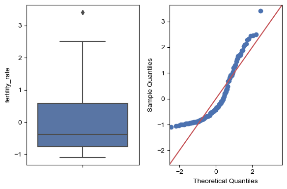

```
+------------------------+---------------------+
| Descriptive Statistics |                     |
+------------------------+---------------------+
|      Sample Size       |         143         |
|          Mean          |         0.0         |
|         Median         |        -0.389       |
|          Mode          |  -0.846159661981771 |
|          Max           |   3.41454146050464  |
|          Min           | -1.1005801738929715 |
|         Range          |        4.515        |
|   Standard Deviation   |        1.004        |
|        Variance        |        1.007        |
+------------------------+---------------------+

Using the IQR Method, the following outliers were identified:
 The lower bound is: -2.7753
 The upper bound is: 2.5937
 Unique Outliers are: {3.41454146050464}
 The total number of outliers are: 1
```

```python
# outlier detection
outlier(df_standard['fertility_rate'])
```

```python
# winsorizing
winsor_try(df_standard['fertility_rate'])
```

```
Winsorizing at 1%
Outliers: set()
 number of outliers = 0 | Upper bound= 2.594 | Lower bound = -2.775

Winsorizing at 2.5%
Outliers: set()
 number of outliers = 0 | Upper bound= 2.594 | Lower bound = -2.775

Winsorizing at 5%
Outliers: set()
 number of outliers = 0 | Upper bound= 2.594 | Lower bound = -2.775

Winsorizing at 10%
Outliers: set()
 number of outliers = 0 | Upper bound= 2.594 | Lower bound = -2.775

Winsorizing at 15%
Outliers: set()
 number of outliers = 0 | Upper bound= 2.594 | Lower bound = -2.775
```

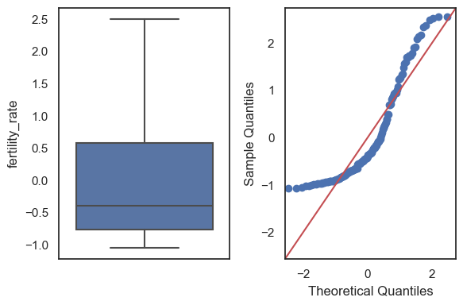

```
+------------------------+---------------------+
| Descriptive Statistics |                     |
+------------------------+---------------------+
|      Sample Size       |         143         |
|          Mean          |        -0.006       |
|         Median         |        -0.389       |
|          Mode          | -1.0466632442164256 |
|          Max           |  2.501323464108145  |
|          Min           | -1.0466632442164256 |
|         Range          |        3.548        |
|   Standard Deviation   |        0.984        |
|        Variance        |        0.968        |
+------------------------+---------------------+

Using the IQR Method, the following outliers were identified:
 The lower bound is: -2.7753
 The upper bound is: 2.5937
 Unique Outliers are: set()
 The total number of outliers are: 0
```

```python
# winsorize at 1%
df_standard['fertility_rate'] = winsorize(df_standard['fertility_rate'],
                      limits = [.01,.01])

# check again
outlier(df_standard['fertility_rate'])
```

##### Median Age

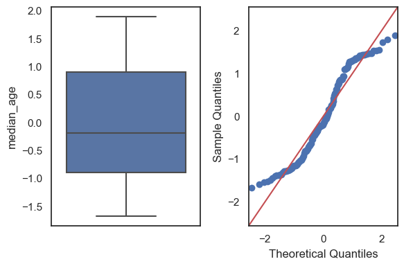

```
+------------------------+---------------------+
| Descriptive Statistics |                     |
+------------------------+---------------------+
|      Sample Size       |         143         |
|          Mean          |         -0.0        |
|         Median         |        -0.185       |
|          Mode          | -0.8035323805845855 |
|          Max           |  1.8936226800110822 |
|          Min           |  -1.670054028269886 |
|         Range          |        3.564        |
|   Standard Deviation   |        1.004        |
|        Variance        |        1.007        |
+------------------------+---------------------+

Using the IQR Method, the following outliers were identified:
 The lower bound is: -3.5796
 The upper bound is: 3.6041
 Unique Outliers are: set()
 The total number of outliers are: 0
```

```python
outlier(df_standard['median_age'])
```

##### Crude birth rate

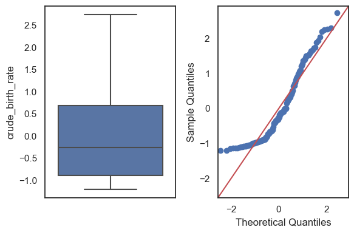

```
+------------------------+---------------------+
| Descriptive Statistics |                     |
+------------------------+---------------------+
|      Sample Size       |         143         |
|          Mean          |         -0.0        |
|         Median         |        -0.254       |
|          Mode          | -1.2033404323835015 |
|          Max           |  2.7360870865582494 |
|          Min           | -1.2033404323835015 |
|         Range          |        3.939        |
|   Standard Deviation   |        1.004        |
|        Variance        |        1.007        |
+------------------------+---------------------+

Using the IQR Method, the following outliers were identified:
 The lower bound is: -3.2601
 The upper bound is: 3.0521
 Unique Outliers are: set()
 The total number of outliers are: 0
```

```python
outlier(df_standard['crude_birth_rate'])
```

##### Life expectancy at birth

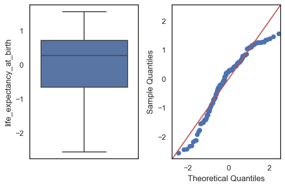

```
+------------------------+---------------------+
| Descriptive Statistics |                     |
+------------------------+---------------------+
|      Sample Size       |         143         |
|          Mean          |         -0.0        |
|         Median         |        0.274        |
|          Mode          | -1.4096775845810108 |
|          Max           |  1.5633417689541205 |
|          Min           | -2.5549739021292894 |
|         Range          |        4.118        |
|   Standard Deviation   |        1.004        |
|        Variance        |        1.007        |
+------------------------+---------------------+

Using the IQR Method, the following outliers were identified:
 The lower bound is: -2.7108
 The upper bound is: 2.7745
 Unique Outliers are: set()
 The total number of outliers are: 0
```

```python
outlier(df_standard['life_expectancy_at_birth'])
```

##### Infant mortality rate

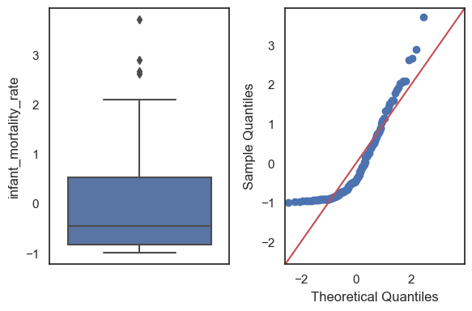

```
+------------------------+---------------------+
| Descriptive Statistics |                     |
+------------------------+---------------------+
|      Sample Size       |         143         |
|          Mean          |         0.0         |
|         Median         |        -0.437       |
|          Mode          | -0.9789353419534818 |
|          Max           |  3.7197807329679686 |
|          Min           | -0.9789353419534818 |
|         Range          |        4.699        |
|   Standard Deviation   |        1.004        |
|        Variance        |        1.007        |
+------------------------+---------------------+

Using the IQR Method, the following outliers were identified:
 The lower bound is: -2.8299
 The upper bound is: 2.5527
 Unique Outliers are: {2.6370496224808173, 2.6861676018520293, 3.7197807329679686, 2.9011477434477686}
 The total number of outliers are: 4
```

```python
# outlier check
outlier(df_standard['infant_mortality_rate'])
```

```python
# finding the best winsorize limit
winsor_try(df_standard['infant_mortality_rate'])
```

```
Winsorizing at 1%
Outliers: {2.6370496224808173, 2.9011477434477686, 2.6861676018520293}
 number of outliers = 4 | Upper bound= 2.553 | Lower bound = -2.83

Winsorizing at 2.5%
Outliers: {2.6370496224808173}
 number of outliers = 4 | Upper bound= 2.553 | Lower bound = -2.83

Winsorizing at 5%
Outliers: set()
 number of outliers = 0 | Upper bound= 2.553 | Lower bound = -2.83

Winsorizing at 10%
Outliers: set()
 number of outliers = 0 | Upper bound= 2.553 | Lower bound = -2.83

Winsorizing at 15%
Outliers: set()
 number of outliers = 0 | Upper bound= 2.553 | Lower bound = -2.83
```

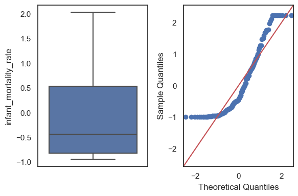

```
+------------------------+---------------------+
| Descriptive Statistics |                     |
+------------------------+---------------------+
|      Sample Size       |         143         |
|          Mean          |        -0.027       |
|         Median         |        -0.437       |
|          Mode          | -0.9390714746377155 |
|          Max           |  2.0329222047073596 |
|          Min           | -0.9390714746377155 |
|         Range          |        2.972        |
|   Standard Deviation   |        0.927        |
|        Variance        |        0.859        |
+------------------------+---------------------+

Using the IQR Method, the following outliers were identified:
 The lower bound is: -2.8299
 The upper bound is: 2.5527
 Unique Outliers are: set()
 The total number of outliers are: 0
```

```python
# best when winsorize at 5%
df_standard['infant_mortality_rate'] = winsorize(df_standard['infant_mortality_rate'],
                      limits = [.05,.05])

# check again
outlier(df_standard['infant_mortality_rate'])
```

##### Crude death rate

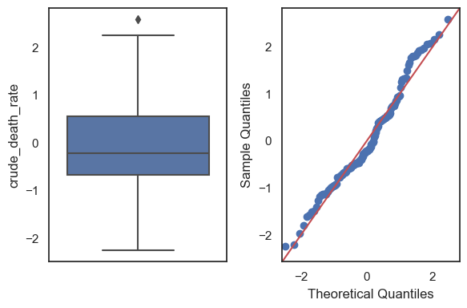

```
+------------------------+---------------------+
| Descriptive Statistics |                     |
+------------------------+---------------------+
|      Sample Size       |         143         |
|          Mean          |         0.0         |
|         Median         |        -0.213       |
|          Mode          |  0.4851118555733797 |
|          Max           |  2.5808222614788074 |
|          Min           | -2.2385340430105765 |
|         Range          |        4.819        |
|   Standard Deviation   |        1.004        |
|        Variance        |        1.007        |
+------------------------+---------------------+

Using the IQR Method, the following outliers were identified:
 The lower bound is: -2.4825
 The upper bound is: 2.3777
 Unique Outliers are: {2.5808222614788074}
 The total number of outliers are: 1
```

```python
outlier(df_standard['crude_death_rate'])
```

```python
# finding the best winsorized limit
winsor_try(df_standard['crude_death_rate'])
```

```
Winsorizing at 1%
Outliers: set()
 number of outliers = 0 | Upper bound= 2.378 | Lower bound = -2.483

Winsorizing at 2.5%
Outliers: set()
 number of outliers = 0 | Upper bound= 2.378 | Lower bound = -2.483

Winsorizing at 5%
Outliers: set()
 number of outliers = 0 | Upper bound= 2.378 | Lower bound = -2.483

Winsorizing at 10%
Outliers: set()
 number of outliers = 0 | Upper bound= 2.378 | Lower bound = -2.483

Winsorizing at 15%
Outliers: set()
 number of outliers = 0 | Upper bound= 2.378 | Lower bound = -2.483
```

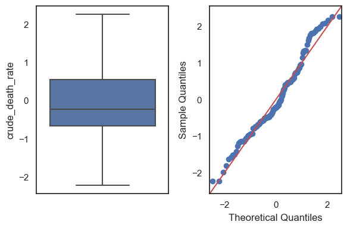

```
+------------------------+---------------------+
| Descriptive Statistics |                     |
+------------------------+---------------------+
|      Sample Size       |         143         |
|          Mean          |        -0.002       |
|         Median         |        -0.213       |
|          Mode          |  0.4851118555733797 |
|          Max           |  2.2581061878421638 |
|          Min           | -2.2015966610883098 |
|         Range          |         4.46        |
|   Standard Deviation   |        0.997        |
|        Variance        |        0.995        |
+------------------------+---------------------+

Using the IQR Method, the following outliers were identified:
 The lower bound is: -2.4825
 The upper bound is: 2.3777
 Unique Outliers are: set()
 The total number of outliers are: 0
```

```python
# best when winsorize at 1%
df_standard['crude_death_rate'] = winsorize(df_standard['crude_death_rate'],
                      limits = [.01,.01])

# check again
outlier(df_standard['crude_death_rate'])
```

##### Net migration rate

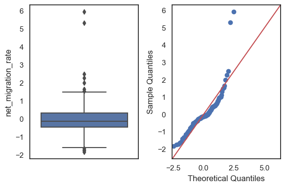

```
+------------------------+----------------------+
| Descriptive Statistics |                      |
+------------------------+----------------------+
|      Sample Size       |         143          |
|          Mean          |         -0.0         |
|         Median         |        -0.106        |
|          Mode          | -0.23917564663918517 |
|          Max           |  5.939410719989994   |
|          Min           | -1.8130038421734511  |
|         Range          |        7.752         |
|   Standard Deviation   |        1.004         |
|        Variance        |        1.007         |
+------------------------+----------------------+

Using the IQR Method, the following outliers were identified:
 The lower bound is: -1.6289
 The upper bound is: 1.531
 Unique Outliers are: {1.5443644140448383, 2.28626959735766, 1.6729613124857274, 2.0053348346098714, 2.5078519454404224, 5.939410719989994, 5.320167193651558, -1.7417809445754202, -1.8130038421734511, -1.6339573912672902, -1.7160615648872422}
 The total number of outliers are: 11
```

```python
outlier(df_standard['net_migration_rate'])
```

```python
# finding the best winsorize limit
winsor_try(df_standard['net_migration_rate'])
```

```
Winsorizing at 1%
Outliers: {1.5443644140448383, 2.28626959735766, 1.6729613124857274, 2.0053348346098714, 2.5078519454404224, 5.320167193651558, -1.7417809445754202, -1.6339573912672902, -1.7160615648872422}
 number of outliers = 11 | Upper bound= 1.531 | Lower bound = -1.629

Winsorizing at 2.5%
Outliers: {1.5443644140448383, 2.28626959735766, 2.0053348346098714, 1.6729613124857274, -1.6339573912672902}
 number of outliers = 11 | Upper bound= 1.531 | Lower bound = -1.629

Winsorizing at 5%
Outliers: set()
 number of outliers = 0 | Upper bound= 1.531 | Lower bound = -1.629

Winsorizing at 10%
Outliers: set()
 number of outliers = 0 | Upper bound= 1.531 | Lower bound = -1.629

Winsorizing at 15%
Outliers: set()
 number of outliers = 0 | Upper bound= 1.531 | Lower bound = -1.629
```

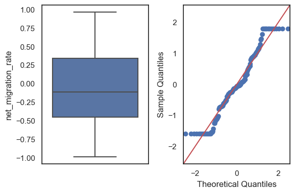

```
+------------------------+--------------------+
| Descriptive Statistics |                    |
+------------------------+--------------------+
|      Sample Size       |        143         |
|          Mean          |       -0.069       |
|         Median         |       -0.106       |
|          Mode          | -0.981080829952007 |
|          Max           | 0.9646891641497536 |
|          Min           | -0.981080829952007 |
|         Range          |       1.946        |
|   Standard Deviation   |       0.576        |
|        Variance        |       0.331        |
+------------------------+--------------------+

Using the IQR Method, the following outliers were identified:
 The lower bound is: -1.6289
 The upper bound is: 1.531
 Unique Outliers are: set()
 The total number of outliers are: 0
```

```python
# best to winsorize at 10%
df_standard['net_migration_rate'] = winsorize(df_standard['net_migration_rate'],
                      limits = [.10,.10])

# check again
outlier(df_standard['net_migration_rate'])
```

##### Happiness

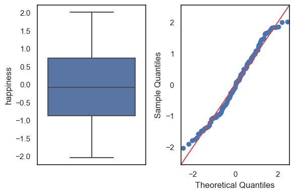

```
+------------------------+---------------------+
| Descriptive Statistics |                     |
+------------------------+---------------------+
|      Sample Size       |         143         |
|          Mean          |         -0.0        |
|         Median         |        -0.072       |
|          Mode          | -2.0271761803338504 |
|          Max           |  2.020241827222283  |
|          Min           | -2.0271761803338504 |
|         Range          |        4.047        |
|   Standard Deviation   |        1.004        |
|        Variance        |        1.007        |
+------------------------+---------------------+

Using the IQR Method, the following outliers were identified:
 The lower bound is: -3.2763
 The upper bound is: 3.1662
 Unique Outliers are: set()
 The total number of outliers are: 0
```

```python
outlier(df_standard['happiness'])
```

##### Log GDP

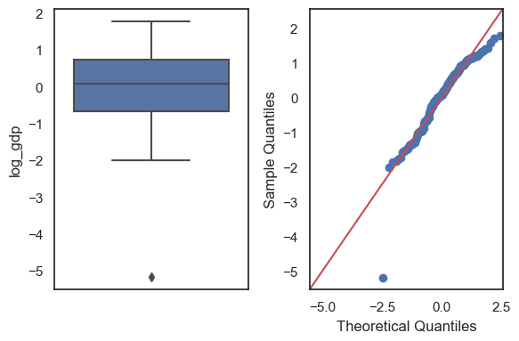

```
+------------------------+--------------------+
| Descriptive Statistics |                    |
+------------------------+--------------------+
|      Sample Size       |        143         |
|          Mean          |        -0.0        |
|         Median         |       0.077        |
|          Mode          | -5.172778348164044 |
|          Max           | 1.7712040255634767 |
|          Min           | -5.172778348164044 |
|         Range          |       6.944        |
|   Standard Deviation   |       1.004        |
|        Variance        |       1.007        |
+------------------------+--------------------+

Using the IQR Method, the following outliers were identified:
 The lower bound is: -2.8061
 The upper bound is: 2.8699
 Unique Outliers are: {-5.172778348164044}
 The total number of outliers are: 1
```

```python
# outlier check
outlier(df_standard['log_gdp'])
```

```python
# find the limit to winsorize
winsor_try(df_standard['log_gdp'])
```

```
Winsorizing at 1%
Outliers: set()
 number of outliers = 0 | Upper bound= 2.87 | Lower bound = -2.806

Winsorizing at 2.5%
Outliers: set()
 number of outliers = 0 | Upper bound= 2.87 | Lower bound = -2.806

Winsorizing at 5%
Outliers: set()
 number of outliers = 0 | Upper bound= 2.87 | Lower bound = -2.806

Winsorizing at 10%
Outliers: set()
 number of outliers = 0 | Upper bound= 2.87 | Lower bound = -2.806

Winsorizing at 15%
Outliers: set()
 number of outliers = 0 | Upper bound= 2.87 | Lower bound = -2.806
```

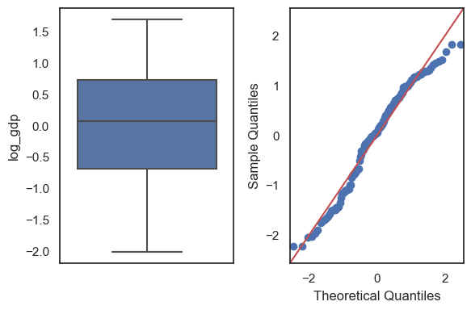

```
+------------------------+--------------------+
| Descriptive Statistics |                    |
+------------------------+--------------------+
|      Sample Size       |        143         |
|          Mean          |       0.022        |
|         Median         |       0.077        |
|          Mode          | -2.008474422510596 |
|          Max           | 1.7005676578305515 |
|          Min           | -2.008474422510596 |
|         Range          |       3.709        |
|   Standard Deviation   |       0.919        |
|        Variance        |       0.845        |
+------------------------+--------------------+

Using the IQR Method, the following outliers were identified:
 The lower bound is: -2.8061
 The upper bound is: 2.8699
 Unique Outliers are: set()
 The total number of outliers are: 0
```

```python
# winsorizing at 1%
df_standard['log_gdp'] = winsorize(df_standard['log_gdp'],
                      limits = [.01,.01])

# check
outlier(df_standard['log_gdp'])
```

##### Social Support

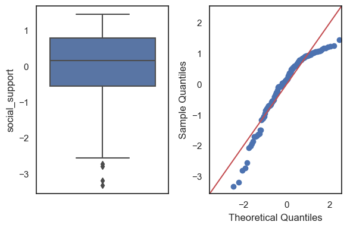

```
+------------------------+---------------------+
| Descriptive Statistics |                     |
+------------------------+---------------------+
|      Sample Size       |         143         |
|          Mean          |         0.0         |
|         Median         |        0.167        |
|          Mode          | -3.3125790903601224 |
|          Max           |  1.453055674064913  |
|          Min           | -3.3125790903601224 |
|         Range          |        4.766        |
|   Standard Deviation   |        1.004        |
|        Variance        |        1.007        |
+------------------------+---------------------+

Using the IQR Method, the following outliers were identified:
 The lower bound is: -2.5865
 The upper bound is: 2.8331
 Unique Outliers are: {-3.3125790903601224, -2.789200073718875, -3.185277064200541, -2.7129920580587172}
 The total number of outliers are: 4
```

```python
# check outlier
outlier(df_standard['social_support'])
```

```python
# best limit for winsorize
winsor_try(df_standard['social_support'])
```

```
Winsorizing at 1%
Outliers: {-2.789200073718875, -3.185277064200541, -2.7129920580587172}
 number of outliers = 4 | Upper bound= 2.833 | Lower bound = -2.587

Winsorizing at 2.5%
Outliers: {-2.7129920580587172}
 number of outliers = 4 | Upper bound= 2.833 | Lower bound = -2.587

Winsorizing at 5%
Outliers: set()
 number of outliers = 0 | Upper bound= 2.833 | Lower bound = -2.587

Winsorizing at 10%
Outliers: set()
 number of outliers = 0 | Upper bound= 2.833 | Lower bound = -2.587

Winsorizing at 15%
Outliers: set()
 number of outliers = 0 | Upper bound= 2.833 | Lower bound = -2.587
```

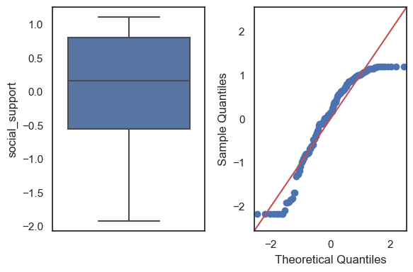

```
+------------------------+---------------------+
| Descriptive Statistics |                     |
+------------------------+---------------------+
|      Sample Size       |         143         |
|          Mean          |        0.029        |
|         Median         |        0.167        |
|          Mode          | -1.9168033035389982 |
|          Max           |  1.1066198177510584 |
|          Min           | -1.9168033035389982 |
|         Range          |        3.023        |
|   Standard Deviation   |        0.901        |
|        Variance        |        0.812        |
+------------------------+---------------------+

Using the IQR Method, the following outliers were identified:
 The lower bound is: -2.5865
 The upper bound is: 2.8331
 Unique Outliers are: set()
 The total number of outliers are: 0
```

```python
# best to winsorize at 5%
df_standard['social_support'] = winsorize(df_standard['social_support'],
                      limits = [.05,.05])

# check
outlier(df_standard['social_support'])
```

##### Healthy Life Expectancy

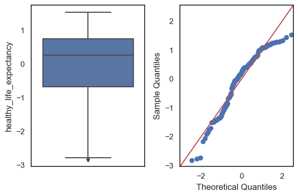

```
+------------------------+--------------------+
| Descriptive Statistics |                    |
+------------------------+--------------------+
|      Sample Size       |        143         |
|          Mean          |        -0.0        |
|         Median         |       0.261        |
|          Mode          | -2.816838041692797 |
|          Max           | 1.5300468597130354 |
|          Min           | -2.816838041692797 |
|         Range          |       4.347        |
|   Standard Deviation   |       1.004        |
|        Variance        |       1.007        |
+------------------------+--------------------+

Using the IQR Method, the following outliers were identified:
 The lower bound is: -2.8085
 The upper bound is: 2.8929
 Unique Outliers are: {-2.816838041692797}
 The total number of outliers are: 1
```

```python
outlier(df_standard['healthy_life_expectancy'])
```

```python
# find the best limit
winsor_try(df_standard['healthy_life_expectancy'])
```

```
Winsorizing at 1%
Outliers: set()
 number of outliers = 0 | Upper bound= 2.893 | Lower bound = -2.808

Winsorizing at 2.5%
Outliers: set()
 number of outliers = 0 | Upper bound= 2.893 | Lower bound = -2.808

Winsorizing at 5%
Outliers: set()
 number of outliers = 0 | Upper bound= 2.893 | Lower bound = -2.808

Winsorizing at 10%
Outliers: set()
 number of outliers = 0 | Upper bound= 2.893 | Lower bound = -2.808

Winsorizing at 15%
Outliers: set()
 number of outliers = 0 | Upper bound= 2.893 | Lower bound = -2.808
```

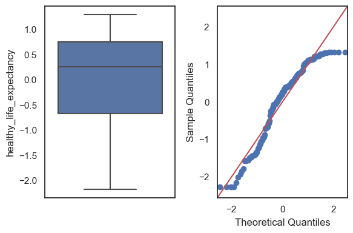

```
+------------------------+---------------------+
| Descriptive Statistics |                     |
+------------------------+---------------------+
|      Sample Size       |         143         |
|          Mean          |         0.01        |
|         Median         |        0.261        |
|          Mode          | -2.1717382505166754 |
|          Max           |  1.2955991168578216 |
|          Min           | -2.1717382505166754 |
|         Range          |        3.467        |
|   Standard Deviation   |        0.968        |
|        Variance        |        0.936        |
+------------------------+---------------------+

Using the IQR Method, the following outliers were identified:
 The lower bound is: -2.8085
 The upper bound is: 2.8929
 Unique Outliers are: set()
 The total number of outliers are: 0
```

```python
# best to winsorize at 2.5%
df_standard['healthy_life_expectancy'] = winsorize(df_standard['healthy_life_expectancy'],
                      limits = [.025,.025])

# check
outlier(df_standard['healthy_life_expectancy'])
```

##### Freedom

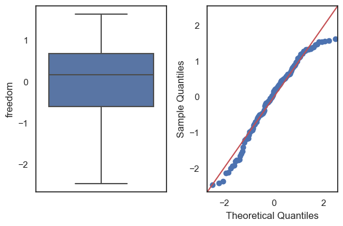

```
+------------------------+---------------------+
| Descriptive Statistics |                     |
+------------------------+---------------------+
|      Sample Size       |         143         |
|          Mean          |         -0.0        |
|         Median         |        0.167        |
|          Mode          | -0.1602540015161098 |
|          Max           |  1.632751973687102  |
|          Min           |  -2.458962320135267 |
|         Range          |        4.092        |
|   Standard Deviation   |        1.004        |
|        Variance        |        1.007        |
+------------------------+---------------------+

Using the IQR Method, the following outliers were identified:
 The lower bound is: -2.5275
 The upper bound is: 2.615
 Unique Outliers are: set()
 The total number of outliers are: 0
```

```python
outlier(df_standard['freedom'])
```

##### Corruption Perception

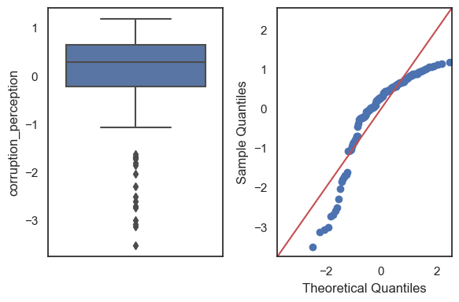

```
+------------------------+----------------------+
| Descriptive Statistics |                      |
+------------------------+----------------------+
|      Sample Size       |         143          |
|          Mean          |         -0.0         |
|         Median         |        0.299         |
|          Mode          | 0.024795562674473182 |
|          Max           |  1.1857394462611786  |
|          Min           |  -3.504185909110426  |
|         Range          |         4.69         |
|   Standard Deviation   |        1.004         |
|        Variance        |        1.007         |
+------------------------+----------------------+

Using the IQR Method, the following outliers were identified:
 The lower bound is: -1.5251
 The upper bound is: 1.9574
 Unique Outliers are: {-1.7148583558647772, -1.607673698029769, -1.8342230884537638, -3.1083854539510956, -3.504185909110426, -1.6610340255233877, -2.9922309014920727, -2.014247270257068, -2.5879957146571013, -2.27490979312389, -2.6836963020097873, -1.6779701294670146, -2.491135120184989, -3.0623226…
 The total number of outliers are: 16
```

```python
outlier(df_standard['corruption_perception'])
```

```python
# find best limit to winsorize
winsor_try(df_standard['corruption_perception'])
```

```
Winsorizing at 1%
Outliers: {-1.7148583558647772, -1.607673698029769, -1.8342230884537638, -3.1083854539510956, -1.6610340255233877, -2.9922309014920727, -2.014247270257068, -2.5879957146571013, -2.27490979312389, -2.6836963020097873, -1.6779701294670146, -2.491135120184989, -3.062322625790596, -2.7248997548918164, -…
 number of outliers = 16 | Upper bound= 1.957 | Lower bound = -1.525

Winsorizing at 2.5%
Outliers: {-1.7148583558647772, -1.607673698029769, -1.8342230884537638, -1.6610340255233877, -2.9922309014920727, -2.014247270257068, -2.5879957146571013, -2.27490979312389, -2.6836963020097873, -1.6779701294670146, -2.491135120184989, -2.7248997548918164, -1.7905181143365476}
 number of outliers = 16 | Upper bound= 1.957 | Lower bound = -1.525

Winsorizing at 5%
Outliers: {-1.7148583558647772, -1.607673698029769, -1.8342230884537638, -1.6610340255233877, -2.491135120184989, -2.27490979312389, -1.6779701294670146, -2.014247270257068, -1.7905181143365476}
 number of outliers = 16 | Upper bound= 1.957 | Lower bound = -1.525

Winsorizing at 10%
Outliers: {-1.607673698029769, -1.6610340255233877}
 number of outliers = 16 | Upper bound= 1.957 | Lower bound = -1.525

Winsorizing at 15%
Outliers: set()
 number of outliers = 0 | Upper bound= 1.957 | Lower bound = -1.525
```

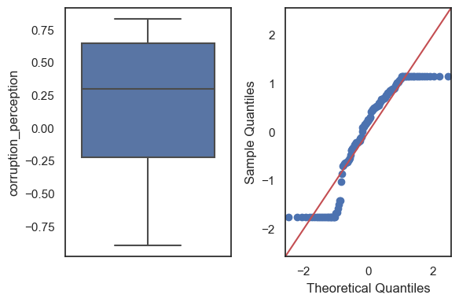

```
+------------------------+---------------------+
| Descriptive Statistics |                     |
+------------------------+---------------------+
|      Sample Size       |         143         |
|          Mean          |        0.148        |
|         Median         |        0.299        |
|          Mode          | -0.8926453096152762 |
|          Max           |  0.8326810441067881 |
|          Min           | -0.8926453096152762 |
|         Range          |        1.725        |
|   Standard Deviation   |        0.599        |
|        Variance        |        0.359        |
+------------------------+---------------------+

Using the IQR Method, the following outliers were identified:
 The lower bound is: -1.5251
 The upper bound is: 1.9574
 Unique Outliers are: set()
 The total number of outliers are: 0
```

```python
# best to winsorize at 15%
df_standard['corruption_perception'] = winsorize(df_standard['corruption_perception'],
                      limits = [.15,.15])

# check
outlier(df_standard['corruption_perception'])
```

# Exploratory Data Analysis

### Q1. What are the top 10 happiest countries in the world?

```python
# Top 10 countries with highest happiness scores
df.sort_values('happiness',ascending = False).head(10)[['country','region','continent','happiness']].reset_index()
```

|  | index | country | region | continent | happiness |
| --- | --- | --- | --- | --- | --- |
| 0 | 38 | Denmark | Northern Europe | Europe | 7.65 |
| 1 | 47 | Finland | Northern Europe | Europe | 7.63 |
| 2 | 110 | Norway | Northern Europe | Europe | 7.47 |
| 3 | 62 | Iceland | Northern Europe | Europe | 7.47 |
| 4 | 140 | Switzerland | Western Europe | Europe | 7.46 |
| 5 | 104 | Netherlands | Western Europe | Europe | 7.45 |
| 6 | 139 | Sweden | Northern Europe | Europe | 7.38 |
| 7 | 25 | Canada | Northern America | North America | 7.30 |
| 8 | 68 | Israel | Western Asia | Asia | 7.28 |
| 9 | 105 | New Zealand | Australia and New Zealand | Oceania | 7.27 |

### Q2. What are the top 10 richest countries in the world?

```python
# Top 10 countries with highest GDP
df.sort_values('log_gdp',ascending = False).head(10)[['country','region','continent','log_gdp']].reset_index()
```

|  | index | country | region | continent | log_gdp |
| --- | --- | --- | --- | --- | --- |
| 0 | 86 | Luxembourg | Western Europe | Europe | 11.64 |
| 1 | 119 | Qatar | Western Asia | Asia | 11.55 |
| 2 | 127 | Singapore | South-eastern Asia | Asia | 11.38 |
| 3 | 67 | Ireland | Northern Europe | Europe | 11.17 |
| 4 | 140 | Switzerland | Western Europe | Europe | 11.14 |
| 5 | 153 | United Arab Emirates | Western Asia | Asia | 11.09 |
| 6 | 110 | Norway | Northern Europe | Europe | 11.07 |
| 7 | 155 | United States | Northern America | North America | 10.98 |
| 8 | 77 | Kuwait | Western Asia | Asia | 10.94 |
| 9 | 104 | Netherlands | Western Europe | Europe | 10.90 |

### Q3. What are the top 10 countries with highest population in the world as of 2023?

```python
# grab all population of 2023
m = population_orig[population_orig['year'] == 2023]

# transform the dtype of 'population' from object to number
m['population'] = m['population'].apply(pd.to_numeric, errors='coerce')

# apply dictionary
m = m.merge(dictionary_df, on = 'country', how = 'left')

# sort values
m.sort_values('population', ascending = False).reset_index().head(10)[['country','population','region','continent']]
```

|  | country | population | region | continent |
| --- | --- | --- | --- | --- |
| 0 | China | 1413142846 | Eastern Asia | Asia |
| 1 | India | 1399179585 | Southern Asia | Asia |
| 2 | United States | 339665118 | Northern America | North America |
| 3 | Indonesia | 279476346 | South-eastern Asia | Asia |
| 4 | Pakistan | 247653551 | Southern Asia | Asia |
| 5 | Nigeria | 230842743 | Western Africa | Africa |
| 6 | Brazil | 218689757 | South America | South America |
| 7 | Bangladesh | 167184465 | Southern Asia | Asia |
| 8 | Russia | 141505279 | Eastern Europe | Europe |
| 9 | Mexico | 129875529 | Central America | North America |

### Q4. What are some indicators of happiness?

```
There is 10 variables (with r >= 0.30) correlated with happiness:
log_gdp                     0.85
life_expectancy_at_birth    0.81
social_support              0.79
healthy_life_expectancy     0.79
median_age                  0.69
freedom                     0.65
net_migration_rate          0.50
fertility_rate             -0.66
crude_birth_rate           -0.70
infant_mortality_rate      -0.75
Name: happiness, dtype: float64
```

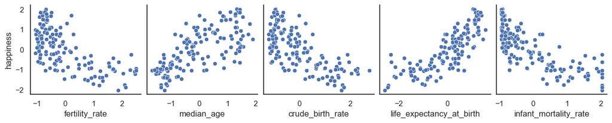

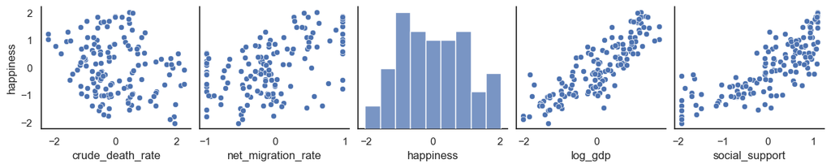

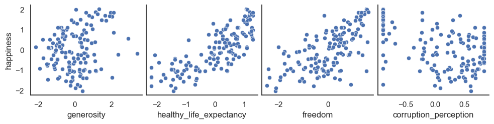

```python
# only display factors with correlation >= .5
correport(df_standard,
          var = 'happiness',
          threshold = .3)
```

# DATA ANALYSIS

### Determining Alpha

Alpha will be set at .05 for Statistical Analysis

```python
# adjusted alpha
number_of_test = 1
number_of_posthoc = 0
threshold_for_one_test = .05

# calculate alpha
alpha = threshold_for_one_test/(number_of_test + number_of_posthoc)
method = 'normal'   #
print('Adjusted Alpha value using %s method for %i statistical tests: %.2e' %(method,number_of_test,alpha))
```

```
Adjusted Alpha value using normal method for 1 statistical tests: 5.00e-02
```

### The Multiple Linear Model

```python
# the model
multiple_lr(df_standard, outcome = 'happiness')
```

```
 ==========================================
               RESULT REPORTING
 ==========================================
 A multiple linear regression model to predict happiness from multiple predictors was significant, F(13,129) = 62.222, p < 0.05.
 This model explains 84.86 percent of variance in happiness, Adjusted R-squared = 0.849.


                            OLS Regression Results
==============================================================================
Dep. Variable:              happiness   R-squared:                       0.862
Model:                            OLS   Adj. R-squared:                  0.849
Method:                 Least Squares   F-statistic:                     62.22
Date:                Mon, 22 Jan 2024   Prob (F-statistic):           4.92e-49
Time:                        11:07:14   Log-Likelihood:                -61.065
No. Observations:                 143   AIC:                             150.1
Df Residuals:                     129   BIC:                             191.6
Df Model:                          13
Covariance Type:            nonrobust
============================================================================================
                               coef    std err          t      P>|t|      [0.025      0.975]
--------------------------------------------------------------------------------------------
const                        0.0089      0.035      0.258      0.797      -0.059       0.077
fertility_rate               0.2616      0.259      1.008      0.315      -0.252       0.775
median_age                  -0.5234      0.243     -2.157      0.033      -1.003      -0.043
crude_birth_rate            -0.3455      0.349     -0.991      0.324      -1.035       0.344
life_expectancy_at_birth     0.6896      0.202      3.409      0.001       0.289       1.090
infant_mortality_rate        0.2096      0.132      1.586      0.115      -0.052       0.471
crude_death_rate             0.2868      0.115      2.496      0.014       0.059       0.514
net_migration_rate           0.0139      0.077      0.181      0.857      -0.138       0.166
log_gdp                      0.4989      0.109      4.570      0.000       0.283       0.715
social_support               0.2765      0.069      4.009      0.000       0.140       0.413
generosity                   0.0965      0.040      2.396      0.018       0.017       0.176
healthy_life_expectancy      0.0308      0.123      0.251      0.802      -0.212       0.273
freedom                      0.2095      0.047      4.476      0.000       0.117       0.302
corruption_perception       -0.1310      0.070     -1.876      0.063      -0.269       0.007
==============================================================================
Omnibus:                        3.935   Durbin-Watson:                   2.170
Prob(Omnibus):                  0.140   Jarque-Bera (JB):                3.720
Skew:                          -0.244   Prob(JB):                        0.156
Kurtosis:                       3.621   Cond. No.                         34.9
```

[output cut: 21 more lines]

```
 For every unit increase in social_support, happiness increases by 0.276 unit.

generosity significantly predicts happiness, t(13,129) = 2.40, p <0.05.
 For every unit increase in generosity, happiness increases by 0.097 unit.

freedom significantly predicts happiness, t(13,129) = 4.48, p <0.05.
 For every unit increase in freedom, happiness increases by 0.210 unit.

In total, 7 out of 13 predictors were significant.

 ==============================================
             INSIGNIFICANT PREDICTORS
 ==============================================
These remaining 6 predictors do not significantly predict happiness, p > 0.05
 ['fertility_rate', 'crude_birth_rate', 'infant_mortality_rate', 'net_migration_rate', 'healthy_life_expectancy', 'corruption_perception']
```

### Result Reporting

A multiple linear regression model to predict happiness from fertility rate, median age, crude birth rate, life expectancy at birth, infant mortality rate, crude death rate, net migration rate, GDP, social support, generosity, healthy life expectancy, freedom to make life choices, and perception of corruption was significant, F(13,129) = 62.222, *p* < .05. This model explains 84.86 percent of variance in happiness, adjusted R-squared = .849.

Using alpha at .05 for statistical significant threshold, seven out of 13 predictors significantly predict happiness.

1. **Median age** significantly predicts happiness, *t*(13,129) = -2.16, *p* <.05. For every unit increase in median age, happiness decreases by .523 unit. Country with a younger population tend to be happier.
2. **Life expectancy at birth** significantly predicts happiness, *t*(13,129) = 3.41, *p* <.05. For every unit increase in life expectancy at birth, happiness increases by .690 unit. Life expectancy at birth refers to the number of years a newborn infant would live if prevailing patterns of mortality at the time of its birth were to stay the same throughout its life. In country where newborn babies are expected to live a longer life, its citizens tend to feel happier.
3. **Death rate** significantly predicts happiness, *t*(13,129) = 2.50, *p* <.05. For every unit increase in crude death rate, happiness increases by .287 unit. In country where the death rate is higher, its citizen reports to be more happy.
4. **GDP** significantly predicts happiness, *t*(13,129) = 4.57, *p* <.05. For every unit increase in log GDP, happiness increases by .499 unit. GDP is a measure of how prosperous a country is. People report happier when their country's economic is doing better.
5. **Social support** significantly predicts happiness, *t*(13,129) = 4.01, *p* <.05. For every unit increase in social_support, happiness increases by .276 unit. People report to be more happy if they live in a country where they receive more social support.
6. **Generosity** significantly predicts happiness, *t*(13,129) = 2.40, *p* <.05. For every unit increase in generosity, happiness increases by .097 unit. People report to be more happy if they perceive a higher degree of generosity from other people.
7. **Freedom to make life choices** significantly predicts happiness, *t*(13,129) = 4.48, *p* <.05. For every unit increase in freedom, happiness increases by .210 unit. In countries where people exercises a higher degree of freedom, they tend to be more happy.

Fertility rate, birth rate, infant mortality rate, migration rate, healthy life expectancy, and perception of corruption do not significantly predict happiness, p >.05.

# DISCUSSION

### Expected Findings

Aligned with common knowledge, people tend to feel happier in countries with higher GDP, social support, generosity, freedom to make life choices, and higher life expectancy at birth. A *high GDP* is a strong indicator of a good economy; therefore, its citizen can benefit financially (i.e., jobs). *Higher life expectancy at birth* indicates better healthcare services for its citizen; therefore, the wellbeing of its citizen are being taken care of. In country where there are a lot of*social support* and *generosity* among its citizen, people reported feel happier because they are likely to feel that they are being watched out for. In country where people exercise more *freedom*, people reports feeling happier because their human rights are more likely to be protected.

### Novel Findings.

Happy country tends to be associated with a *younger population* (i.e., lower median age) and a *higher death rate*. At the moment, we cannot say for certain the underlying reason behind such a relationship. Future studies should explore this relationship further.

### Limitations

**Correlation does not infer causation.** With the lack of experimental design, I am unable to declare whether any predictors determines a country happiness. It remains unclear whether the above predictors cause people to be happy, or it is because people are happy that cause the above factors to be present.

**Potential of Interaction Effect.** This analysis looked at a person's happiness by multiple factors individually. This analysis does not look at the possible interaction effects between these variables. It is likely that the interaction effect between these variables can offer a more complex answer to the question and provide a richer explanation to the question.

# CONCLUSION

In conclusion, a happy country tend to do better economically, its citizens have more social support, freedom, and life expectancy. It is also unexpected to learn that in a country where there is a lower median age and higher death rate, its citizens tend to report feeling happier.

# REFERENCES

- International database. United States Census Bureau. (n.d.). https://www.census.gov/data-tools/demo/idb/#/table?COUNTRY_YEAR=2024&COUNTRY_YR_ANIM=2024&menu=tableViz&quickReports=CUSTOM&CUSTOM_COLS=POP,MEDAGE,TFR,CBR,E0,IMR,CDR,NMR&TABLE_RANGE=2007,2023&TABLE_YEARS=2007,2008,2009,2010,2011,2012,2013,2014,2015,2016,2017,2018,2019,2020,2021,2022,2023&TABLE_USE_RANGE=Y&TABLE_USE_YEARS=N&TABLE_STEP=1
- Helliwell, J. F., Layard, R., Sachs, J. D., Aknin, L. B., De Neve, J.-E., & Wang, S. (Eds.). (2023). World Happiness Report 2023 (11th ed.). Sustainable Development Solutions Network.
- United Nations. (2019). UNSD — Methodology. Un.org. https://unstats.un.org/unsd/methodology/m49/
- List of Countries by Continent - StatisticsTimes.com. (n.d.). Statisticstimes.com. https://statisticstimes.com/geography/countries-by-continents.php

### Minh K. Chau (2024)